# Observations from analysing tweets by Trump, Obama and Biden

## Brief Overview:

- The goal of this presentation is highlight key observations after having scraped the Twitter feeds of Donald Trump, Barack Obama and Joe Biden via the GetOldTweet3 library. I utilised the wordcloud library inorder to visualise the most common words utilised by the figures inquestion across their most popular tweets.
- The dataset consists of 56,340 tweets dating back form the 1st of Jan 2008 up until 14th September 2020.

### How frequently did Trump, Obama and Biden tweet over the years?

- Obama was quite an active tweeter during his second presidential term (2013 - 2016), particularly during the early years (2013 - 2014). However since leaving office, he has become quite a passive tweeter.
- Trump on the hand has been a highly active tweeter with his frequency of usage exploding from 2013 onwards.
- We can see that Biden only started tweeting from 2012 onwards. Whilst we can see that he was quite an active tweeter during 2012, he very rarely tweeted from 2013 through to 2018 where he spent the majority of this period serving as the Vice President. Though his frequency of usage has certainly increased from 2019 onwards, in the lead up to the 2020 Presidential elections.

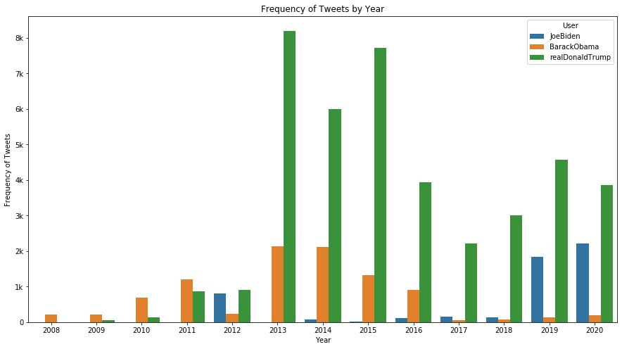

```python
plt.figure(figsize = (15, 8));
palette ={"JoeBiden": "C0", "BarackObama": "C1", "realDonaldTrump": "C2"}
sb.countplot(data = user_names_df_clean, x = 'Year', hue = 'User', palette = palette, hue_order = ["JoeBiden", "BarackObama", "realDonaldTrump"]);
plt.ylabel('Frequency of Tweets');
plt.title('Frequency of Tweets by Year');
plt.yticks(np.arange(0, 8001, 1000), [0,'1k','2k','3k','4k','5k','6k','7k','8k']);
```

### Average number of retweets generated per tweet between Trump, Obama and Biden over the years?

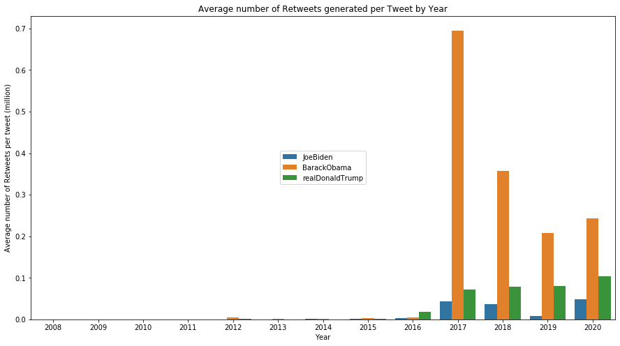

```python
#Plot Retweet per Tweet ratio by year
plt.figure(figsize = (15, 8));
sb.barplot(data = tweet_frequency_retweet, x = 'Year', y = 'Retweet_per_Tweet_ratio', hue = 'User', palette = palette, hue_order = ["JoeBiden", "BarackObama", "realDonaldTrump"]);
plt.ylabel('Average number of Retweets per tweet (million)');
label_range_2 = np.arange(0, 8, 1);
plt.yticks(label_range_2 * 100000, label_range_2 / 10);
plt.title('Average number of Retweets generated per Tweet by Year');
plt.legend(loc='center');
```

### WordCloud to analyse sentiment of the top 250 most retweeted tweets from each user (2017 onwards only)

It isn't at all surprising and a tad bit worrying to see Trumps most retweeted tweets taking a nationalistic tone with words such as 'Make', 'America', 'Great' and 'China' frequently appearing. It is really interesting to see how Biden's most retweeted tweets are those where he is frequently going on the attack against Donald Trump in the build up to the 2020 Presidential elections. This election is certianly proving to be one of the most polarising of modern times.

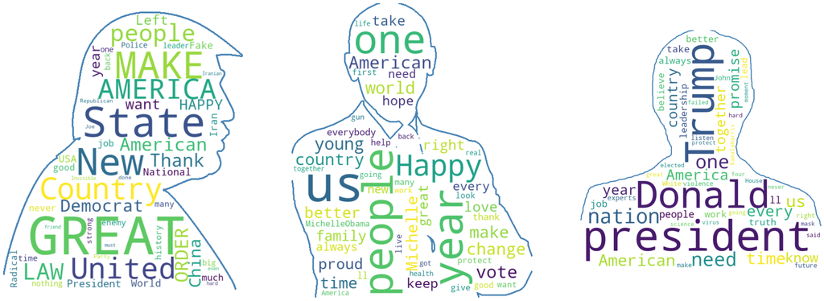

```python
wordcloud_retweet(250, np.arange(2017, 2021, 1), np.arange(2017, 2021, 1), np.arange(2017, 2021, 1))
```